# project_final

*Heart Disease Classification Model*

**Introduction:**

Coronary heart disease lead to many deaths globally every year. Diseases like coronary heart disease and heart attcaks can be caused by the narrowing, or constricting of blood vessels that prevent sufficient blood flow to the heart of a person. The Angiographic disease status is a measure of how constricted, or narrow a persons blood vessels are. The narrower, the higher chances of diseases like heart attack (Kulick).

Since heart disease takes the lives of people every year, being able to predict the angiographic disease status before hand could inform a person if they are likely to suffer from heart disease earlier, giving them an opportunity to take preventative measures early on.

Hence, the question our group aims to answer is how likely are the physical, and measureable attributes of a person to influence whether they develop an angiographic disease diagnosis of greater than 50% narrowing?

This data set we will be using for this investigation consists of different attributes of heart disease patients from different institutes: the Hungarian Institute of Cardiology, the University Hospital in Zurich, Switzerland, the V.A. Medical Centre, Long Beach and the Cleveland Clinic Foundation. It includes data on things such as their age, cholesterol levels, resting ecg measurements, etc. With this data set, we wanted to try and predict the angiographic disease status based on the attributes of patients. This class is labelled as “num” in the data set and has two possible outcomes. If num is equal to 0 this means < 50% diameter narrowing; a num value of 1 means > 50% diameter narrowing. These describe the narrowing of a major vessel. Predicting this class will be achieved by creating a model trained using the patient data from the different institutes (Aha).

Below are the list of all the pakages we will be using for our investigation. The seed we will use throughout our investigation will be 2022

```r
library(tidyverse)
library(repr)
library(tidymodels)
options(repr.matrix.max.rows = 6)
set.seed(2022)
```

[output not shown]

**Method**

The first stage was loading the data sets we would be using for the analysis into Jupyter.

```r
columns = c("age", "sex", "cp", "trestbps", "chol", "fbs",
            "restecg", "maxheartrate", "exang", "oldpeak", "slope", "ca", "thal", "num")
heart_data1 <- read_delim("https://archive.ics.uci.edu/ml/machine-learning-databases/heart-disease/processed.hungarian.data", delim = ",", col_names = columns)
heart_data2 <- read_delim("https://archive.ics.uci.edu/ml/machine-learning-databases/heart-disease/processed.cleveland.data", delim = ",", col_names = columns)
heart_data3 <- read_delim("https://archive.ics.uci.edu/ml/machine-learning-databases/heart-disease/processed.switzerland.data", delim = ",", col_names = columns)
heart_data4 <- read_delim("https://archive.ics.uci.edu/ml/machine-learning-databases/heart-disease/processed.va.data", delim = ",", col_names = columns)
```

```r
heart_data1
```

A spec_tbl_df: 294 × 14

| age <dbl> | sex <dbl> | cp <dbl> | trestbps <chr> | chol <chr> | fbs <chr> | restecg <chr> | maxheartrate <chr> | exang <chr> | oldpeak <dbl> | slope <chr> | ca <chr> | thal <chr> | num <dbl> |
| --- | --- | --- | --- | --- | --- | --- | --- | --- | --- | --- | --- | --- | --- |
| 28 | 1 | 2 | 130 | 132 | 0 | 2 | 185 | 0 | 0 | ? | ? | ? | 0 |
| 29 | 1 | 2 | 120 | 243 | 0 | 0 | 160 | 0 | 0 | ? | ? | ? | 0 |
| 29 | 1 | 2 | 140 | ? | 0 | 0 | 170 | 0 | 0 | ? | ? | ? | 0 |
| ⋮ | ⋮ | ⋮ | ⋮ | ⋮ | ⋮ | ⋮ | ⋮ | ⋮ | ⋮ | ⋮ | ⋮ | ⋮ | ⋮ |
| 56 | 1 | 4 | 155 | 342 | 1 | 0 | 150 | 1 | 3 | 2 | ? | ? | 1 |
| 58 | 0 | 2 | 180 | 393 | 0 | 0 | 110 | 1 | 1 | 2 | ? | 7 | 1 |
| 65 | 1 | 4 | 130 | 275 | 0 | 1 | 115 | 1 | 1 | 2 | ? | ? | 1 |

table 1: Hungarian Institute of Cardiology dataset

```r
heart_data2
```

A spec_tbl_df: 303 × 14

| age <dbl> | sex <dbl> | cp <dbl> | trestbps <dbl> | chol <dbl> | fbs <dbl> | restecg <dbl> | maxheartrate <dbl> | exang <dbl> | oldpeak <dbl> | slope <dbl> | ca <chr> | thal <chr> | num <dbl> |
| --- | --- | --- | --- | --- | --- | --- | --- | --- | --- | --- | --- | --- | --- |
| 63 | 1 | 1 | 145 | 233 | 1 | 2 | 150 | 0 | 2.3 | 3 | 0.0 | 6.0 | 0 |
| 67 | 1 | 4 | 160 | 286 | 0 | 2 | 108 | 1 | 1.5 | 2 | 3.0 | 3.0 | 2 |
| 67 | 1 | 4 | 120 | 229 | 0 | 2 | 129 | 1 | 2.6 | 2 | 2.0 | 7.0 | 1 |
| ⋮ | ⋮ | ⋮ | ⋮ | ⋮ | ⋮ | ⋮ | ⋮ | ⋮ | ⋮ | ⋮ | ⋮ | ⋮ | ⋮ |
| 57 | 1 | 4 | 130 | 131 | 0 | 0 | 115 | 1 | 1.2 | 2 | 1.0 | 7.0 | 3 |
| 57 | 0 | 2 | 130 | 236 | 0 | 2 | 174 | 0 | 0.0 | 2 | 1.0 | 3.0 | 1 |
| 38 | 1 | 3 | 138 | 175 | 0 | 0 | 173 | 0 | 0.0 | 1 | ? | 3.0 | 0 |

table 2: Cleveland Clinic Foundation dataset

```r
heart_data3
```

A spec_tbl_df: 123 × 14

| age <dbl> | sex <dbl> | cp <dbl> | trestbps <chr> | chol <dbl> | fbs <chr> | restecg <chr> | maxheartrate <chr> | exang <chr> | oldpeak <chr> | slope <chr> | ca <chr> | thal <chr> | num <dbl> |
| --- | --- | --- | --- | --- | --- | --- | --- | --- | --- | --- | --- | --- | --- |
| 32 | 1 | 1 | 95 | 0 | ? | 0 | 127 | 0 | .7 | 1 | ? | ? | 1 |
| 34 | 1 | 4 | 115 | 0 | ? | ? | 154 | 0 | .2 | 1 | ? | ? | 1 |
| 35 | 1 | 4 | ? | 0 | ? | 0 | 130 | 1 | ? | ? | ? | 7 | 3 |
| ⋮ | ⋮ | ⋮ | ⋮ | ⋮ | ⋮ | ⋮ | ⋮ | ⋮ | ⋮ | ⋮ | ⋮ | ⋮ | ⋮ |
| 72 | 1 | 3 | 160 | 0 | ? | 2 | 114 | 0 | 1.6 | 2 | 2 | ? | 0 |
| 73 | 0 | 3 | 160 | 0 | 0 | 1 | 121 | 0 | 0 | 1 | ? | 3 | 1 |
| 74 | 1 | 2 | 145 | 0 | ? | 1 | 123 | 0 | 1.3 | 1 | ? | ? | 1 |

table 3: University Hospital, Zurich dataset

```r
heart_data4
```

A spec_tbl_df: 200 × 14

| age <dbl> | sex <dbl> | cp <dbl> | trestbps <chr> | chol <chr> | fbs <chr> | restecg <dbl> | maxheartrate <chr> | exang <chr> | oldpeak <chr> | slope <chr> | ca <chr> | thal <chr> | num <dbl> |
| --- | --- | --- | --- | --- | --- | --- | --- | --- | --- | --- | --- | --- | --- |
| 63 | 1 | 4 | 140 | 260 | 0 | 1 | 112 | 1 | 3 | 2 | ? | ? | 2 |
| 44 | 1 | 4 | 130 | 209 | 0 | 1 | 127 | 0 | 0 | ? | ? | ? | 0 |
| 60 | 1 | 4 | 132 | 218 | 0 | 1 | 140 | 1 | 1.5 | 3 | ? | ? | 2 |
| ⋮ | ⋮ | ⋮ | ⋮ | ⋮ | ⋮ | ⋮ | ⋮ | ⋮ | ⋮ | ⋮ | ⋮ | ⋮ | ⋮ |
| 55 | 1 | 4 | 122 | 223 | 1 | 1 | 100 | 0 | 0 | ? | ? | 6 | 2 |
| 58 | 1 | 4 | ? | 385 | 1 | 2 | ? | ? | ? | ? | ? | ? | 0 |
| 62 | 1 | 2 | 120 | 254 | 0 | 2 | 93 | 1 | 0 | ? | ? | ? | 1 |

table 4: V.A. Medical Center dataset

data combining and wrangling:

The information on the data came from the data documentation on the same database as the data (Aha).

All the data frames will be combined to get 1 data set that can be worked on collectively

slope, ca, and thal are all mostly missing data, so these will not be considered. sex, cp, fbs, restecg, oldpeak and exang are all factor variables that are not important for the clasification model, and will also be selected out. Num(angiographic disease status) is what we will try to predict. It should have only two values, 0 and 1, that was discussed by the data documentation. Since any additional factor values were not described in the documentation, additional values will be filtered out(num = c(2,3,4) are filtered out). The column will be renamed to a more human readable "disease diagnosis," and the column type will be converted to factor. Missing data in the form of "?" will also be filtered out. It could also have been seen that for the cholesterol column, missing data was in the form of either "?" or a 0, so both were filtered out from this. trestbps, chol, and maxheartrate were all changed to numerical values from characters.

```r
heart_disease <- rbind(heart_data1, heart_data2, heart_data3, heart_data4) %>%
select(-slope, -ca, -thal, -sex, -cp, -fbs, -restecg, -exang, -oldpeak) %>%
filter(trestbps != "?", chol != "?", num != "?", num %in% c(0,1), chol != "0")%>%
mutate(num = as_factor(num), trestbps = as.numeric(trestbps),
       chol = as.numeric(chol), maxheartrate = as.numeric(maxheartrate)) %>%
rename(disease_diagnosis = num)
heart_disease
```

A tibble: 543 × 5

| age <dbl> | trestbps <dbl> | chol <dbl> | maxheartrate <dbl> | disease_diagnosis <fct> |
| --- | --- | --- | --- | --- |
| 28 | 130 | 132 | 185 | 0 |
| 29 | 120 | 243 | 160 | 0 |
| 30 | 170 | 237 | 170 | 0 |
| ⋮ | ⋮ | ⋮ | ⋮ | ⋮ |
| 62 | 158 | 170 | 138 | 1 |
| 54 | 127 | 333 | 154 | 1 |
| 62 | 120 | 254 | 93 | 1 |

table 5: Tidy heart disease dataset

Preliminary investigation of the data:

The tidy data was first split into training and testing data. This is so that once we create a model using the training data, we will still have some data that the final model's has never seen before to test the model's accuracy.

For this, we split the data so that we have 75% for training. We believed this to be sufficient data to train the model with. We also wanted to make sure that the proportion of diagnosis' were consistent in both data sets so we get more accurate testing results. This was done by using the strata argument as shown below.

```r
set.seed(2022)
heart_split <- heart_disease %>%
                initial_split(prop = 0.75, strata = disease_diagnosis)
training_data <- training(heart_split)
testing_data <- testing(heart_split)
```

```r
training_data
```

A tibble: 408 × 5

| age <dbl> | trestbps <dbl> | chol <dbl> | maxheartrate <dbl> | disease_diagnosis <fct> |
| --- | --- | --- | --- | --- |
| 29 | 120 | 243 | 160 | 0 |
| 31 | 100 | 219 | 150 | 0 |
| 32 | 105 | 198 | 165 | 0 |
| ⋮ | ⋮ | ⋮ | ⋮ | ⋮ |
| 62 | 158 | 170 | 138 | 1 |
| 54 | 127 | 333 | 154 | 1 |
| 62 | 120 | 254 | 93 | 1 |

table 6: Training data

```r
testing_data
```

A tibble: 135 × 5

| age <dbl> | trestbps <dbl> | chol <dbl> | maxheartrate <dbl> | disease_diagnosis <fct> |
| --- | --- | --- | --- | --- |
| 28 | 130 | 132 | 185 | 0 |
| 30 | 170 | 237 | 170 | 0 |
| 32 | 110 | 225 | 184 | 0 |
| ⋮ | ⋮ | ⋮ | ⋮ | ⋮ |
| 74 | 140 | 237 | 94 | 1 |
| 55 | 120 | 226 | 127 | 1 |
| 68 | 134 | 254 | 151 | 0 |

table 7: Testing data

Once we had our training split, we could investigate what our data looked like.

First we investigated what our actual proportion of data was for for each disease diagnosis(0 or 1)

```r
observation_per_class <- training_data %>%
                            group_by(disease_diagnosis) %>%
                            summarize(n = n())
observation_per_class
```

A tibble: 2 × 2

| disease_diagnosis <fct> | n <int> |
| --- | --- |
| 0 | 267 |
| 1 | 141 |

table 8: observation per class

since there is more data for a diagnosis of 0(< 50% narrowing), about 65.4%, it suggests that the model we create might predict < 50% narrowing majority of the time

Next, we wanted to get an idea of the spread of our predictor variables. To do this, we calculated the mean of all the predictors

```r
mean_data <- training_data %>%
                select(chol, age, trestbps, maxheartrate) %>%
                summarize(chol_avg = mean(chol),
                          age_avg = mean(age),
                          trestbps_avg = mean(trestbps),
                          maxheartrate_avg = mean(maxheartrate))
mean_data
```

A tibble: 1 × 4

| chol_avg <dbl> | age_avg <dbl> | trestbps_avg <dbl> | maxheartrate_avg <dbl> |
| --- | --- | --- | --- |
| 248.9632 | 51.11275 | 131.3431 | 143.8971 |

table 9: means of predictor variables

To follow up on investigating the spread of the data, we plotted the distribution for each predictor by diagnosis

```r
options (repr.plot.width = 20, repr.plot.height = 8)
disease_chol_hist <- ggplot(training_data, aes(x = chol, fill = as_factor(disease_diagnosis)))+
                geom_histogram(binwidth = 50) +
                labs(x = "Cholestrol(mg/dl)", y = "#measurements",
                    fill = "disease diagnosis")+
                theme(text = element_text(size = 30))+
                facet_grid(cols = vars(disease_diagnosis))+
                ggtitle("Distribution of cholestrol")

disease_age_hist <- ggplot(training_data, aes(x = age, fill = as_factor(disease_diagnosis)))+
                geom_histogram(binwidth = 2) +
                labs(x = "age (years)", y = "#measurements",
                    fill = "disease diagnosis")+
                theme(text = element_text(size = 30))+
                facet_grid(cols = vars(disease_diagnosis))+
                ggtitle("Distribution of age")

disease_trestbps_hist <- ggplot(training_data, aes(x = trestbps, fill = as_factor(disease_diagnosis)))+
                geom_histogram(binwidth = 10) +
                labs(x = "rest bps(mm Hg)", y = "#measurements",
                    fill = "disease diagnosis")+
                theme(text = element_text(size = 30))+
                facet_grid(cols = vars(disease_diagnosis))+
                ggtitle("Distribution of resting bps")

disease_maxheartrate_hist <- ggplot(training_data, aes(x = maxheartrate, fill = as_factor(disease_diagnosis)))+
                geom_histogram(binwidth = 5) +
                labs(x = "max heart rate", y = "#measurements",
                    fill = "disease diagnosis")+
                theme(text = element_text(size = 30))+
                facet_grid(cols = vars(disease_diagnosis))+
                ggtitle("Distribution of max heart rate")
```

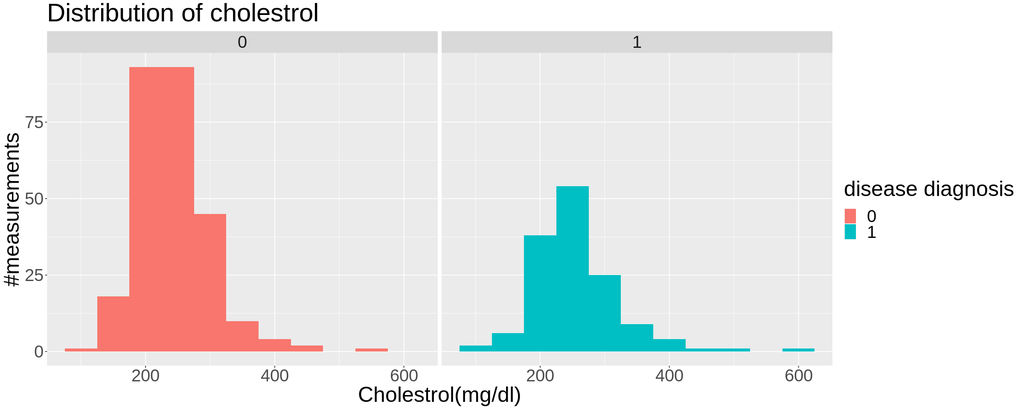

```r
disease_chol_hist
```

plot 1: Diagnosis distribution for cholestrol

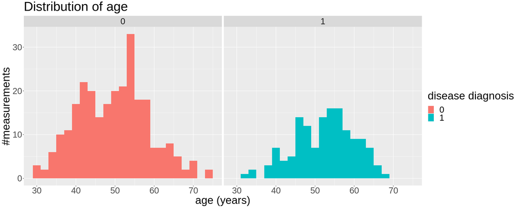

```r
disease_age_hist
```

plot 2: Diagnosis distribution for age

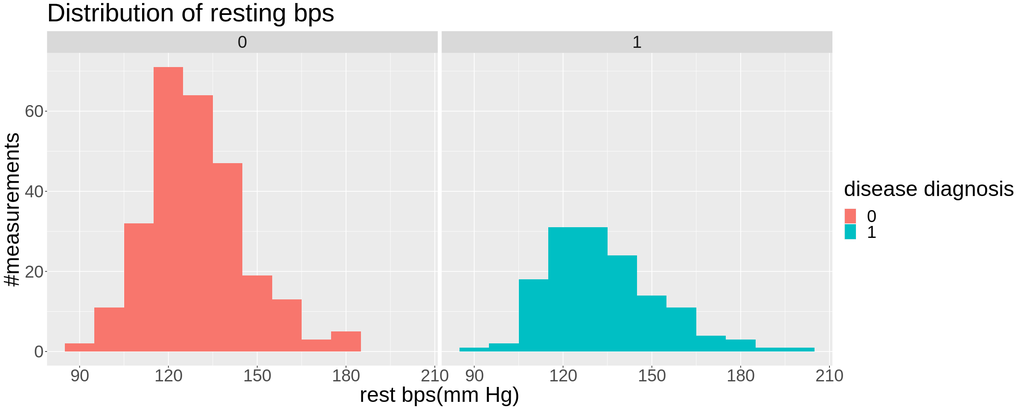

```r
disease_trestbps_hist
```

plot 3: Diagnosis distribution for resting blood pressure

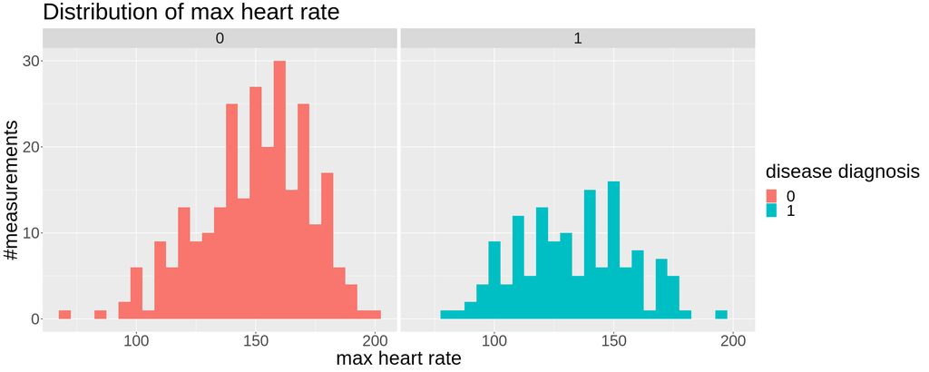

```r
disease_maxheartrate_hist
```

plot 4: diagnosis distribution for max heart rate

The distributions of predictors that vary greatly based on what the respective diagnosis was, should indicate whether the predictor has an influence on the diagnosis, and hence, whether it would be good to use to create the model. Based on the the distributions based on diagnosis above, they don't appear to vary much by shape for every predictor, so there isn't much indication of what predictors might be good for modeling.

Another way to visualize which predictors would make a good model would be to plot them agains each other on scatter plots, and identify which plots have a clear distinction between the two diagnosis groups.

We have 4 predictor variables, so it is possible to make 6 scatter plots. Out of the 6 possible visualizations with our predictors, the ones with the best gradient between types of disease diagnosis are shown below

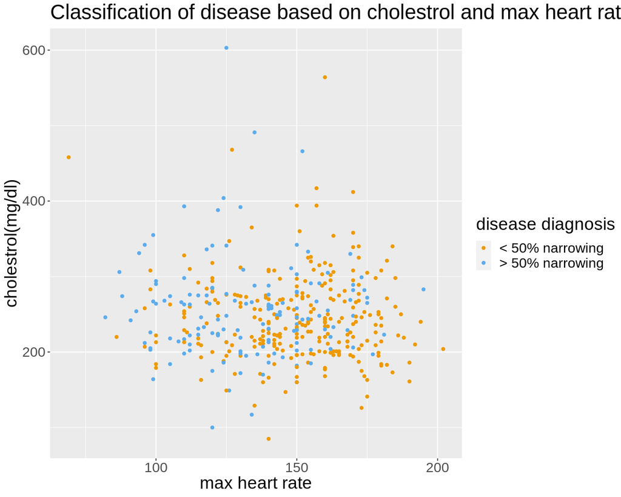

```r
options (repr.plot.width = 10, repr.plot.height = 8)

chol_vs_maxheartrate <- ggplot(training_data, aes(x = maxheartrate, y = chol))+
                geom_point(aes(colour = disease_diagnosis)) +
                labs(x = "max heart rate", y = "cholestrol(mg/dl)",
                    colour = "disease diagnosis")+
                scale_color_manual(labels = c("< 50% narrowing ", "> 50% narrowing"),
                     values = c("orange2", "steelblue2")) +
                theme(text = element_text(size = 20))+
                ggtitle("Classification of disease based on cholestrol and max heart rate")

chol_vs_maxheartrate
```

plot 5: cholestrol vs maximum heart rate

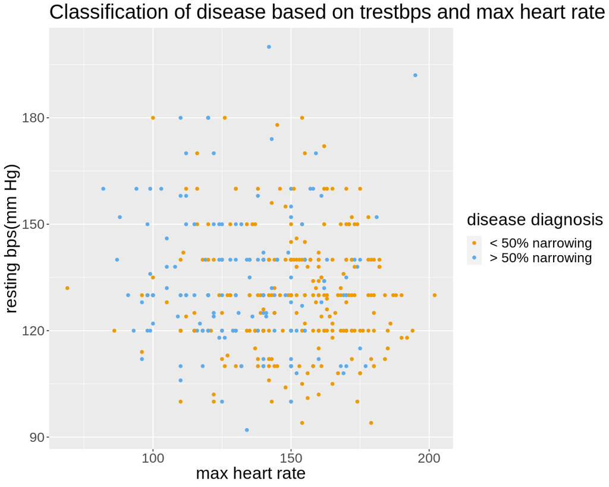

```r
trestbps_vs_maxheartrate <- ggplot(training_data, aes(x = maxheartrate, y = trestbps))+
                geom_point(aes(colour = disease_diagnosis)) +
                labs(x = "max heart rate", y = "resting bps(mm Hg)",
                    colour = "disease diagnosis")+
                scale_color_manual(labels = c("< 50% narrowing ", "> 50% narrowing"),
                     values = c("orange2", "steelblue2")) +
                theme(text = element_text(size = 20))+
                ggtitle("Classification of disease based on trestbps and max heart rate")
trestbps_vs_maxheartrate
```

plot 6: resting bps vs maximum heart rate

Based on the two plots, We felt like the clusters were more evident when plotting cholesterol against max heart rate. Therefore we chose to use these two variables when creating our model.

Another thing we wanted to investigate was was the amount of missing data as it could affect our models accuracy (the less data we have, the more unconfident we are in the models predictions).

```r
set.seed(2022)
training_with_missing <- initial_split(rbind(heart_data1, heart_data2, heart_data3, heart_data4),
                                       prop = 0.75, strata = num) %>%
                         training()
missing_data <- training_with_missing %>%
                            filter(chol == "?" | chol == 0 | maxheartrate == "?") %>%
                            summarize(missing = n())
missing_data
```

A tibble: 1 × 1

| missing <int> |
| --- |
| 184 |

table 10: Missing cholesterol and max heart rate data

Creating the model:

Different predictor variables were used in the model’s creation to discover the ones that would give us the highest accuracies in predicting the class we are interested in. We found that cholesterol levels and max heart rate alone gave us the highest accuracy, and adding other predictors, such as age, decreased the model’s accuracy. Thus, our final and best model uses these two predictor variables only to classify if a patient from the test set has a disease diagnosis of value of < 50% narrowing or > 50% narrowing.

The steps for creating the model are shown below

```r
set.seed(2022)

heart_recipe <- recipe(disease_diagnosis ~  chol + maxheartrate, data = training_data) %>%
   step_scale(all_predictors()) %>%
   step_center(all_predictors())
```

As shown, the predictor variables have been scaled and centered in the recipe, since they have different units. This was done so that they could be compared with an equal weightage.

```r
set.seed(2022)
heart_vfold <- vfold_cv(training_data, v = 5, strata = disease_diagnosis)

gridvals <- tibble(neighbors = seq(1,40))

tune_spec <- nearest_neighbor(weight_func = "rectangular", neighbors = tune()) %>%
      set_engine("kknn") %>%
      set_mode("classification")

heart_accuracy <- workflow() %>%
                  add_recipe(heart_recipe) %>%
                  add_model(tune_spec) %>%
                  tune_grid(resamples = heart_vfold, grid = gridvals) %>%
                  collect_metrics() %>%
                  filter(.metric == "accuracy")
```

To create the model, we are using K-nearest-neighbours classification. For this model to be optimised, we need to find the ideal value for k(number of neighbours). To do this, we used a 5-fold cross validation with k values up to 40

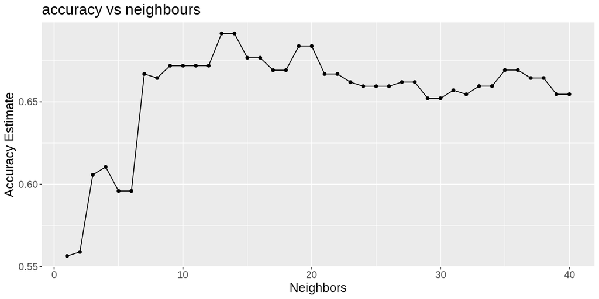

```r
options (repr.plot.width = 10, repr.plot.height = 5)
cross_val_plot <- ggplot(heart_accuracy, aes(x = neighbors, y = mean))+
      geom_point() +
      geom_line() +
      labs(x = "Neighbors", y = "Accuracy Estimate") +
      theme(text = element_text(size = 15)) +
      ggtitle("accuracy vs neighbours")

cross_val_plot
```

plot 7: best K graph

```r
best_k_stats <- heart_accuracy %>%
                filter(mean == max(mean))
best_k <- best_k_stats %>%
            slice(1) %>%
            select(neighbors) %>%
            pull()
best_k_stats
```

A tibble: 2 × 7

| neighbors <int> | .metric <chr> | .estimator <chr> | mean <dbl> | n <int> | std_err <dbl> | .config <chr> |
| --- | --- | --- | --- | --- | --- | --- |
| 13 | accuracy | binary | 0.6914582 | 5 | 0.02340508 | Model13 |
| 14 | accuracy | binary | 0.6914582 | 5 | 0.02340508 | Model14 |

table 11: results of the best k graph

Based on the graph and table above, we found that the highest accuracy was achieved for 13(and 14) neighbours. If k gets any larger than this, the accuracy decreases, and then stagnates. This is a sign of underfitting; when the pattern is not recognised, as farther points gain an influence on the prediction of a new observation.

using this value for k, we fitted the model using the training data, as shown below.

```r
model_spec <- nearest_neighbor(weight_func = "rectangular", neighbors = best_k) %>%
      set_engine("kknn") %>%
      set_mode("classification")
model_fit <- workflow() %>%
      add_recipe(heart_recipe) %>%
      add_model(model_spec) %>%
      fit(data = training_data)
```

Now that the model has been created, we must test to see how accurate our predictions for new observations are. Here we can input values that we know the diagnosis for from our testing data, and then compare the predictions with the actual values to determine the accuracy of our model.

```r
model_predictions <- predict(model_fit, testing_data) %>%
      bind_cols(testing_data)

model_metrics <- model_predictions %>%
        metrics(truth = disease_diagnosis, estimate = .pred_class) %>%
        filter(.metric == "accuracy")

model_conf_mat <- model_predictions %>%
      conf_mat(truth = disease_diagnosis, estimate = .pred_class)
```

```r
model_metrics
```

A tibble: 1 × 3

| .metric <chr> | .estimator <chr> | .estimate <dbl> |
| --- | --- | --- |
| accuracy | binary | 0.7259259 |

table 12: accuracy of the model

We can get a better sense of how these predictions are made for new observations using a confusion matrix.

```r
model_conf_mat
```

```
          Truth
Prediction  0  1
         0 79 27
         1 10 19
```

figure 1: confusion matrix of the model

**Results and Discussion**

From the results of the table above, we can see that our model has a 72.6% accuracy in predicting the angiographic disease status. The number of neighbours used to create the model was 13 due to it having the highest accuracy.

The accuracy that we obtained from our model is good, we found the accuracy to be about 72.6%. The proportion of outcomes in the disease diagnosis class are 267 for the outcome of “< 50% narrowing” and 141 for the outcome of “greater thant 50% narrowing.” This shows a relatively good class balance. Furthermore, the majority classifier would classify a patient as “< 50% narrowing” about 65.4% of the time. This means that our model is better than the majority classifier. This indicates a high level of accuracy. However, a model’s accuracy is relative to its actual purpose and utilisation. For our model, if it were to be actually used in a medical setting, it would not provide reliable enough results. For example, we need to consider that medical tests are required to be as accurate, and precise (which indicates reproducibility), as possible to ensure the patient can be treated accurately. A model accuracy in the low 70% range is unlikely to provide both accuracy and precision in the classification of a patient.

In addition, looking at the confusion matrix for this model, we can see that the model inaccurately predicted the patients as being categorised as "< 50% narrowing," 27 times when in actuality these 27 patients were classified as "> 50% narrowing,". Moreover, it inaccurately predicted "> 50% narrowing," 10 times when in reality these 10 patients were "< 50% narrowing,". Thus, it appears that the model’s biggest problem is classifying some patients as "< 50% narrowing," when they should be classified as "> 50% narrowing,". This instance occurred 20% of the time, which isn't of much use when we are trying to help those who have "> 50% narrowing" of blood vessels. Therefore this model is not ideal to be used in a medical setting.

In terms of the reliability of our training data, it is worth noting that in the training set, there were 184 missing values for chol and maxheartrate. This is a moderately sized chunk of data and this could indicate that the chol and maxheartrate data we have is not sufficient enough to create a highly accurate model. The values of 0 could be arising due to unknown values or as a result of how the data was originally collected, which we cannot change.

For further investigations regarding the data sets we used, there are a number of classes that could be used to create a classification model. Examples of this include trying to classify chest pain, fasting blood sugar, and resting electrocardiographic results. All of these classes can be found in the data sets we used.

With a good model, several hundreds of lives could be saved by predicting early symptoms of heart disease. Models like this can be used to improve medical treatment, and even answer questions about what life styles may lead to higher risks.

**Works cited**

- Daniel Lee Kulick, MD. “Coronary Angiography: What Does a Heart Angiogram Procedure Do?” MedicineNet, MedicineNet, 20 July 2021, https://www.medicinenet.com/coronary_angiogram/article.htm.
- Aha, David, et al. Index of /Ml/Machine-Learning-Databases, 22 July 1988, https://archive.ics.uci.edu/ml/machine-learning-databases/heart-disease/. Accessed 9 Apr. 2022.